# WILD7150 Lecture and Notes

Steven Cabrera

Fall 2022

## Wednesday, August 17, 2022

## Friday, August 19, 2022

## Monday, August 22, 2022

## Wednesday, August 24, 2022

Regression analysis in R. Example: y = biomass (kg), x = rainfall (cm) True relationship would be: y = 2 +3x + $~N(o,sigma) B0 is usually a nuisance parameter, only really useful to best fit the line. B1 = slope r2, variation in y explained in x adjusted r2 takes r2 based on number of x variables in model, in truth x variable is added, r2 goes up. **use multiple r2 when reporting in labs** function confint only produces limits. need to do math to find CI. upper minus lower / 2 **OR** upper - b1, b1- lower, report only one

Generic sentence

**For each 1 [x-unit] increase in [x], we found a [B1] [y-unit] [+/- 95% CI]; 95% CI [increase/decrease] in [y] ([p-value, r<sup>2</sup>])** Include units, specify you gave the CI (some people give SE), for unit rounding - only report two significant figs, use increase/decrease to specify pos or neg slope. If necessary - scale data to make data more interpretable.

```r
data <- read_csv("Lab Data/Lab1/Assign1a.csv")
res <- lm(data = data, WolfSpiders ~ PreySpiders)
summary(res)
```

```
##
## Call:
## lm(formula = WolfSpiders ~ PreySpiders, data = data)
##
## Residuals:
##      Min       1Q   Median       3Q      Max
## -0.76518 -0.20148  0.00088  0.24242  0.50376
##
## Coefficients:
##             Estimate Std. Error t value Pr(>|t|)
## (Intercept)  0.18357    0.09346   1.964   0.0569 .
## PreySpiders  1.91736    0.31724   6.044 4.96e-07 ***
## ---
## Signif. codes:  0 '***' 0.001 '**' 0.01 '*' 0.05 '.' 0.1 ' ' 1
##
## Residual standard error: 0.3159 on 38 degrees of freedom
## Multiple R-squared:  0.4901, Adjusted R-squared:  0.4767
## F-statistic: 36.53 on 1 and 38 DF,  p-value: 4.957e-07
```

```r
anova(res)
```

```
## Analysis of Variance Table
##
## Response: WolfSpiders
##             Df Sum Sq Mean Sq F value    Pr(>F)
## PreySpiders  1 3.6448  3.6448  36.528 4.957e-07 ***
## Residuals   38 3.7917  0.0998
## ---
## Signif. codes:  0 '***' 0.001 '**' 0.01 '*' 0.05 '.' 0.1 ' ' 1
```

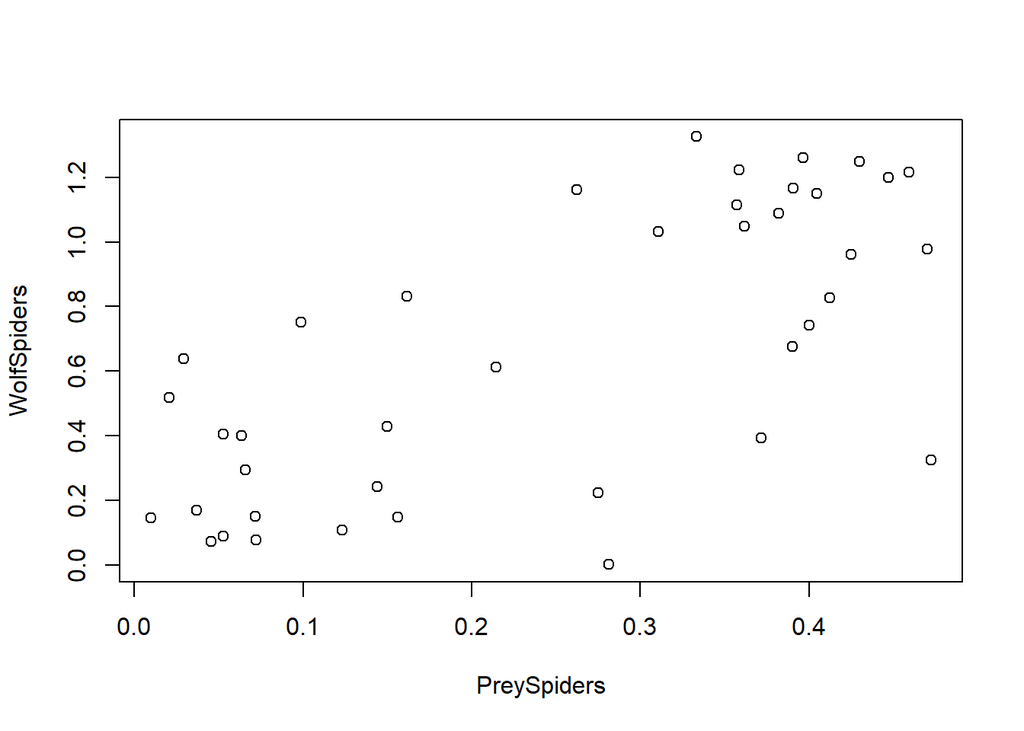

```r
plot <- plot(WolfSpiders ~ PreySpiders, data = data)
```

## LAB - Wednesday, August 24, 2022

Not much going on.

## Friday, August 26, 2022

Scaling is very useful for conveying story message/interpreting the *biological signifigance*  
P-value: probability of getting observed results when the null is true.  
Type I Error: detecting a significant effort when there is none (will happen about 5% of the time).

## Monday, August 29, 2022

## Wednesday, August 31, 2022

## LAB - Wednesday, August 31, 2022